# 3.0 TDI profiles

# TDI profiles

From DES (Divergence Expression Set), one can obtain the TDI profiles through the `mytTAI::TAI` function. The `myTAI` package, to my knowledge, does not enable the flexibility to plot the separate sexes, for example in one plot. Therefore, I will *not* use the `myTAI::PlotSignature` function.

Here, I show the TDI profiles for the developmental stages. For tissues of the adult (matSP) *Fucus* species, one can find them in `3.1 TDI tissues in Fucus matSP`.

```r
library(tidyverse)
library(myTAI)
#  myTAI v1.0.1.9000 2023-07-12 Github (drostlab/myTAI@46eb927)
```

## Load DES

Non-transformed

```r
Fd_DES <-
  readr::read_csv(file = "data/Fd_DES.csv")
Fd_DES_F <-
  readr::read_csv(file = "data/Fd_DES_F.csv")
Fd_DES_M <-
  readr::read_csv(file = "data/Fd_DES_M.csv")
Fs_DES <-
  readr::read_csv(file = "data/Fs_DES.csv")
Fs_DES_F <-
  readr::read_csv(file = "data/Fs_DES_F.csv")
Fs_DES_M <-
  readr::read_csv(file = "data/Fs_DES_M.csv")
Ec_DES_32m <-
  readr::read_csv(file = "data/Ec_DES_32m.csv")
Ec_DES_25f <-
  readr::read_csv(file = "data/Ec_DES_25f.csv")
```

sqrt-tranformed

```r
Fd_DES.sqrt <-
  readr::read_csv(file = "data/Fd_DES.sqrt.csv")
Fd_DES_F.sqrt <-
  readr::read_csv(file = "data/Fd_DES_F.sqrt.csv")
Fd_DES_M.sqrt <-
  readr::read_csv(file = "data/Fd_DES_M.sqrt.csv")
Fs_DES.sqrt <-
  readr::read_csv(file = "data/Fs_DES.sqrt.csv")
Fs_DES_F.sqrt <-
  readr::read_csv(file = "data/Fs_DES_F.sqrt.csv")
Fs_DES_M.sqrt <-
  readr::read_csv(file = "data/Fs_DES_M.sqrt.csv")
Ec_DES_32m.sqrt <-
  readr::read_csv(file = "data/Ec_DES_32m.sqrt.csv")
Ec_DES_25f.sqrt <-
  readr::read_csv(file = "data/Ec_DES_25f.sqrt.csv")
```

log2-tranformed

```r
Fd_DES.log2 <-
  readr::read_csv(file = "data/Fd_DES.log2.csv")
Fd_DES_F.log2 <-
  readr::read_csv(file = "data/Fd_DES_F.log2.csv")
Fd_DES_M.log2 <-
  readr::read_csv(file = "data/Fd_DES_M.log2.csv")
Fs_DES.log2 <-
  readr::read_csv(file = "data/Fs_DES.log2.csv")
Fs_DES_F.log2 <-
  readr::read_csv(file = "data/Fs_DES_F.log2.csv")
Fs_DES_M.log2 <-
  readr::read_csv(file = "data/Fs_DES_M.log2.csv")
Ec_DES_32m.log2 <-
  readr::read_csv(file = "data/Ec_DES_32m.log2.csv")
Ec_DES_25f.log2 <-
  readr::read_csv(file = "data/Ec_DES_25f.log2.csv")
```

rank-tranformed

```r
Fd_DES.rank <-
  readr::read_csv(file = "data/Fd_DES.rank.csv")
Fd_DES_F.rank <-
  readr::read_csv(file = "data/Fd_DES_F.rank.csv")
Fd_DES_M.rank <-
  readr::read_csv(file = "data/Fd_DES_M.rank.csv")
Fs_DES.rank <-
  readr::read_csv(file = "data/Fs_DES.rank.csv")
Fs_DES_F.rank <-
  readr::read_csv(file = "data/Fs_DES_F.rank.csv")
Fs_DES_M.rank <-
  readr::read_csv(file = "data/Fs_DES_M.rank.csv")
Ec_DES_32m.rank <-
  readr::read_csv(file = "data/Ec_DES_32m.rank.csv")
Ec_DES_25f.rank <-
  readr::read_csv(file = "data/Ec_DES_25f.rank.csv")
```

rlog-tranformed

```r
Fd_DES.rlog <-
  readr::read_csv(file = "data/Fd_DES.rlog.csv")
Fd_DES_F.rlog <-
  readr::read_csv(file = "data/Fd_DES_F.rlog.csv")
Fd_DES_M.rlog <-
  readr::read_csv(file = "data/Fd_DES_M.rlog.csv")
Fs_DES.rlog <-
  readr::read_csv(file = "data/Fs_DES.rlog.csv")
Fs_DES_F.rlog <-
  readr::read_csv(file = "data/Fs_DES_F.rlog.csv")
Fs_DES_M.rlog <-
  readr::read_csv(file = "data/Fs_DES_M.rlog.csv")
Ec_DES_32m.rlog <-
  readr::read_csv(file = "data/Ec_DES_32m.rlog.csv")
Ec_DES_25f.rlog <-
  readr::read_csv(file = "data/Ec_DES_25f.rlog.csv")
```

# TDI calculation

I had previously used a function to combine males and females into one TDI plot.

```r
#TI stands for transcriptome index
TI.preplot <- function(ExpressionSet, permutations = 50000){
  std <-
    myTAI::bootMatrix(
      ExpressionSet = ExpressionSet,
      permutations  = permutations) %>%
    apply(2, stats::sd)
  TI.out <-
    myTAI::TDI(ExpressionSet) %>%
    tibble::as_tibble(rownames = "Stage", colnames = c("TDI", "PS")) %>%
    dplyr::bind_cols(as_tibble(std)) %>%
    dplyr::rename(TDI = 2, sd = 3)
  return(TI.out)
}
```

### Fucus distichus

```r
# function to process Fd. This will be changed to accommodate more seq data.
get_TDI_Fd <- function(DES_all, DES_M, DES_F, ordered_stages){
  TDI_b <-
    TI.preplot(
      dplyr::select(DES_all, !c("gamete"))) %>%
    dplyr::mutate(Sex = "Mixed")
  stages_to_NA <- # this will differ for Fucus serratus
    ordered_stages[-c(1, 1+1)]
  TDI_M <-
    TI.preplot(
      DES_M) %>%
    tibble::add_row(
      dplyr::filter(
        dplyr::select(TDI_b, !Sex),
        Stage == ordered_stages[1+1])) %>%
    tibble::add_row(
      tibble::tibble(Stage = stages_to_NA, TDI = NA, sd = NA)
    ) %>%
    dplyr::mutate(Sex = "Male")
  TDI_F <-
    TI.preplot(
      DES_F) %>%
    tibble::add_row(
      dplyr::filter(
        dplyr::select(TDI_b, !Sex),
        Stage == ordered_stages[1+1])) %>%
    tibble::add_row(
      tibble::tibble(Stage = stages_to_NA, TDI = NA, sd = NA)
    ) %>%
    dplyr::mutate(Sex = "Female") # This is not true - this is needed for the plotting.
  TDI_out <-
    dplyr::bind_rows(TDI_b, TDI_M, TDI_F)
  TDI_out$Stage <- base::factor(TDI_out$Stage, ordered_stages)
  return(TDI_out)
}
```

```r
ordered_stages <- colnames(Fd_DES)[3:ncol(Fd_DES)]
Fd_TDI <-
  get_TDI_Fd(
    DES_all = Fd_DES,
    DES_M = Fd_DES_M,
    DES_F = Fd_DES_F,
    ordered_stages)
Fd_TDI.log2 <-
  get_TDI_Fd(
    DES_all = Fd_DES.log2,
    DES_M = dplyr::rename(Fd_DES_M.log2, gamete = V1),
    DES_F = dplyr::rename(Fd_DES_F.log2, gamete = V1),
    ordered_stages)
Fd_TDI.sqrt <-
  get_TDI_Fd(
    DES_all = Fd_DES.sqrt,
    DES_M = dplyr::rename(Fd_DES_M.sqrt, gamete = V1),
    DES_F = dplyr::rename(Fd_DES_F.sqrt, gamete = V1),
    ordered_stages)
Fd_TDI.rank <-
  get_TDI_Fd(
    DES_all = Fd_DES.rank,
    DES_M = dplyr::rename(Fd_DES_M.rank, gamete = V1),
    DES_F = dplyr::rename(Fd_DES_F.rank, gamete = V1),
    ordered_stages)
Fd_TDI.rlog <-
  get_TDI_Fd(
    DES_all = Fd_DES.rlog,
    DES_M = Fd_DES_M.rlog,
    DES_F = Fd_DES_F.rlog,
    ordered_stages)
```

As I previously noted `dplyr::rename()` is used due to a bug I found in myTAI.

### Fucus serratus

```r
# function to process Fd. This will be changed to accommodate more seq data.
get_TDI_Fs <- function(DES_all, DES_M, DES_F, ordered_stages){
  TDI_b <-
    TI.preplot(
      dplyr::select(DES_all, !c("gamete","matSP"))) %>%
    dplyr::mutate(Sex = "Mixed")
  stages_to_NA <- # this will differ for Fucus distichus
    ordered_stages[-c(1, 1+1, length(ordered_stages) - 1, length(ordered_stages))]
  TDI_M <-
    TI.preplot(
      DES_M) %>%
    tibble::add_row(
      dplyr::filter(
        dplyr::select(TDI_b, !Sex),
        Stage %in% c(
          ordered_stages[1+1],
          ordered_stages[length(ordered_stages) - 1]))) %>%
    tibble::add_row(
      tibble::tibble(Stage = stages_to_NA, TDI = NA, sd = NA)
    ) %>%
    dplyr::mutate(Sex = "Male")
  TDI_F <-
    TI.preplot(
      DES_F) %>%
    tibble::add_row(
      dplyr::filter(
        dplyr::select(TDI_b, !Sex),
        Stage %in% c(
          ordered_stages[1+1],
          ordered_stages[length(ordered_stages) - 1]))) %>%
    tibble::add_row(
      tibble::tibble(Stage = stages_to_NA, TDI = NA, sd = NA)
    ) %>%
    dplyr::mutate(Sex = "Female") # This is not true. this is needed for the plotting.
  TDI_out <-
    dplyr::bind_rows(TDI_b, TDI_M, TDI_F)
  TDI_out$Stage <- base::factor(TDI_out$Stage, ordered_stages)
  return(TDI_out)
}
```

```r
ordered_stages <- colnames(Fs_DES)[3:ncol(Fs_DES)]
Fs_TDI <-
  get_TDI_Fs(
    DES_all = Fs_DES,
    DES_M = Fs_DES_M,
    DES_F = Fs_DES_F,
    ordered_stages)
Fs_TDI.log2 <-
  get_TDI_Fs(
    DES_all = Fs_DES.log2,
    DES_M = Fs_DES_M.log2,
    DES_F = Fs_DES_F.log2,
    ordered_stages)
Fs_TDI.sqrt <-
  get_TDI_Fs(
    DES_all = Fs_DES.sqrt,
    DES_M = Fs_DES_M.sqrt,
    DES_F = Fs_DES_F.sqrt,
    ordered_stages)
Fs_TDI.rank <-
  get_TDI_Fs(
    DES_all = Fs_DES.rank,
    DES_M = Fs_DES_M.rank,
    DES_F = Fs_DES_F.rank,
    ordered_stages)
Fs_TDI.rlog <-
  get_TDI_Fs(
    DES_all = Fs_DES.rlog,
    DES_M = Fs_DES_M.rlog,
    DES_F = Fs_DES_F.rlog,
    ordered_stages)
```

### Ectocarpus

```r
# function to process Fd. This will be changed to accommodate more seq data.
get_TDI_Ec <- function(DES_M, DES_F, ordered_stages){
  TDI_M <-
    TI.preplot(DES_M) %>%
    dplyr::mutate(Sex = "Male")
  TDI_F <-
    TI.preplot(DES_F) %>%
    dplyr::mutate(Sex = "Female")
  stages_to_NA <- # this will differ for Fucus distichus
    ordered_stages[-c(1, 1+1, length(ordered_stages) - 1, length(ordered_stages))]
  TDI_out <-
    dplyr::bind_rows(TDI_M, TDI_F)
  TDI_out$Stage <- base::factor(TDI_out$Stage, ordered_stages)
  return(TDI_out)
}
```

```r
ordered_stages <- colnames(Ec_DES_25f)[3:ncol(Ec_DES_25f)]

Ec_TDI <-
  get_TDI_Ec(
    DES_M = Ec_DES_32m,
    DES_F = Ec_DES_25f,
    ordered_stages)
Ec_TDI.sqrt <-
  get_TDI_Ec(
    DES_M = Ec_DES_32m.sqrt,
    DES_F = Ec_DES_25f.sqrt,
    ordered_stages)
Ec_TDI.log2 <-
  get_TDI_Ec(
    DES_M = Ec_DES_32m.log2,
    DES_F = Ec_DES_25f.log2,
    ordered_stages)
Ec_TDI.rank <-
  get_TDI_Ec(
    DES_M = Ec_DES_32m.rank,
    DES_F = Ec_DES_25f.rank,
    ordered_stages)
Ec_TDI.rlog <-
  get_TDI_Ec(
    DES_M = Ec_DES_32m.rlog,
    DES_F = Ec_DES_25f.rlog,
    ordered_stages)
```

# TDI profiles

## Fucus serratus

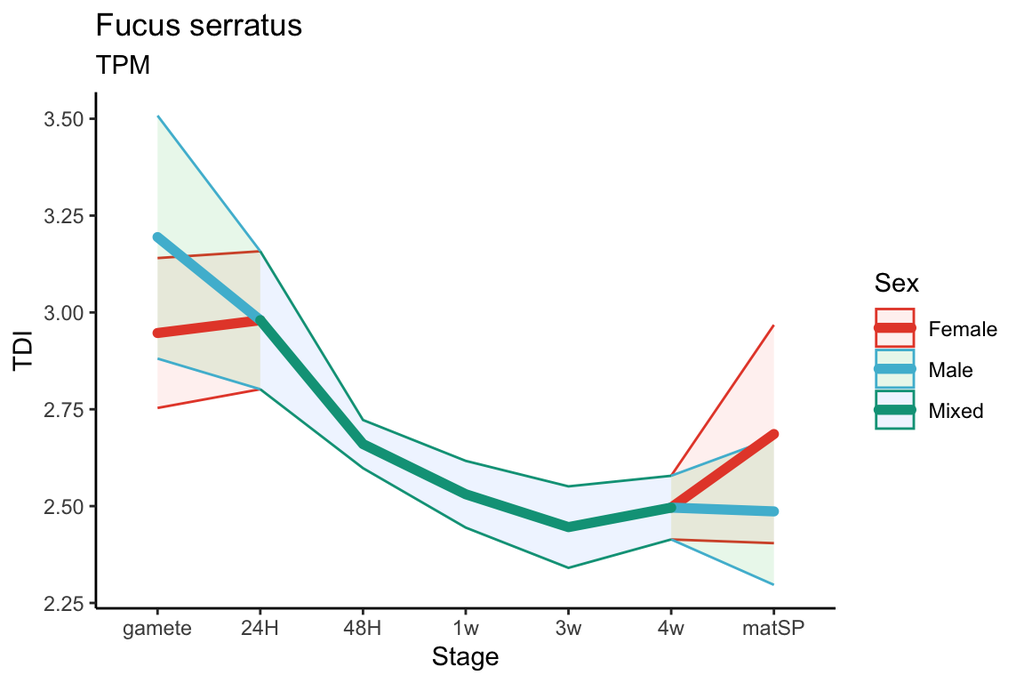

```r
Fs_TDI %>%
  ggplot2::ggplot(
    aes(
      y = TDI,
      x = Stage,
      group = Sex,
      colour = Sex,
      fill = Sex)) +
  ggplot2::geom_ribbon(
    aes(ymin = TDI - sd,
        ymax = TDI + sd
        ), alpha = 0.1) +
  ggplot2::geom_line(size = 2, lineend = "round") +
  theme_classic() +
  ggsci::scale_colour_npg() +
  labs(title = "Fucus serratus",
       subtitle = "TPM")
```

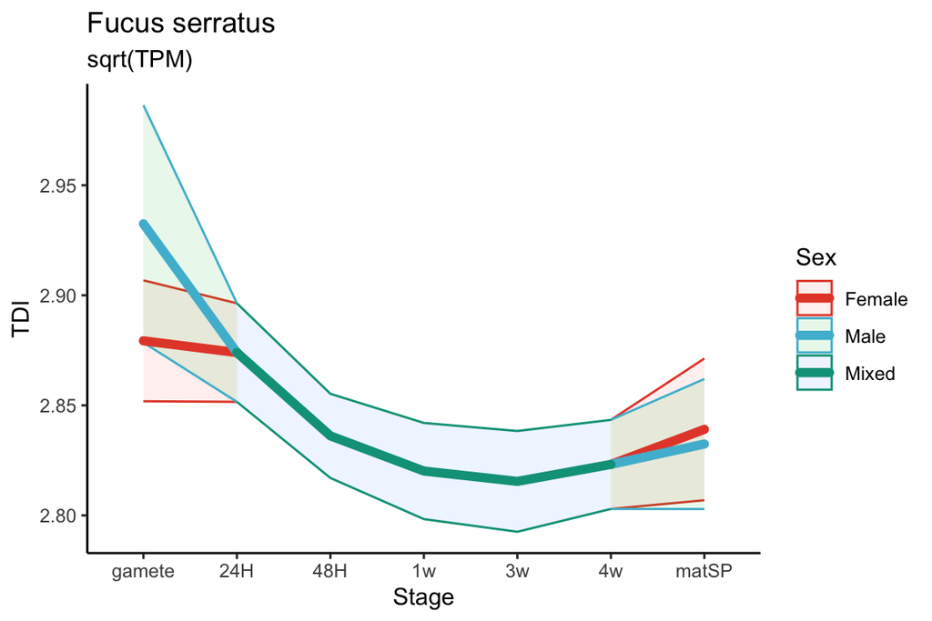

```r
Fs_TDI.sqrt %>%
  ggplot2::ggplot(
    aes(
      y = TDI,
      x = Stage,
      group = Sex,
      colour = Sex,
      fill = Sex)) +
  ggplot2::geom_ribbon(
    aes(ymin = TDI - sd,
        ymax = TDI + sd
        ), alpha = 0.1) +
  ggplot2::geom_line(size = 2, lineend = "round") +
  theme_classic() +
  ggsci::scale_colour_npg() +
  labs(title = "Fucus serratus",
       subtitle = "sqrt(TPM)")
```

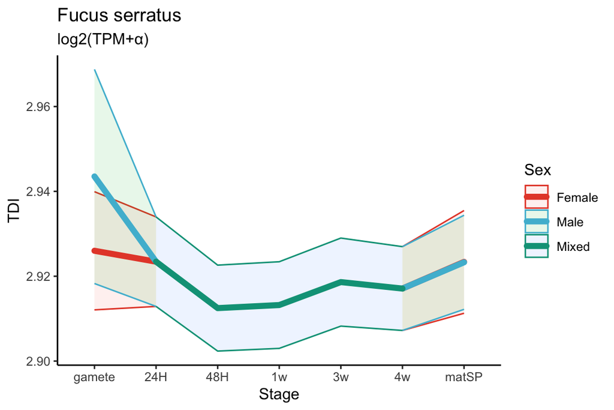

```r
Fs_TDI.log2 %>%
  ggplot2::ggplot(
    aes(
      y = TDI,
      x = Stage,
      group = Sex,
      colour = Sex,
      fill = Sex)) +
  ggplot2::geom_ribbon(
    aes(ymin = TDI - sd,
        ymax = TDI + sd
        ), alpha = 0.1) +
  ggplot2::geom_line(size = 2, lineend = "round") +
  theme_classic() +
  ggsci::scale_colour_npg() +
  labs(title = "Fucus serratus",
       subtitle = "log2(TPM+\u03b1)")
```

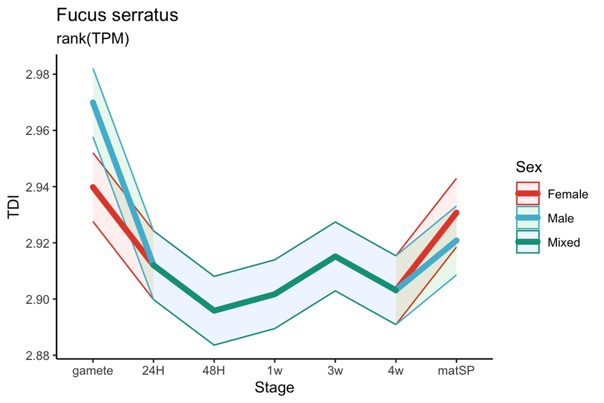

```r
Fs_TDI.rank %>%
  ggplot2::ggplot(
    aes(
      y = TDI,
      x = Stage,
      group = Sex,
      colour = Sex,
      fill = Sex)) +
  ggplot2::geom_ribbon(
    aes(ymin = TDI - sd,
        ymax = TDI + sd
        ), alpha = 0.1) +
  ggplot2::geom_line(size = 2, lineend = "round") +
  theme_classic() +
  ggsci::scale_colour_npg() +
  labs(title = "Fucus serratus",
       subtitle = "rank(TPM)")
```

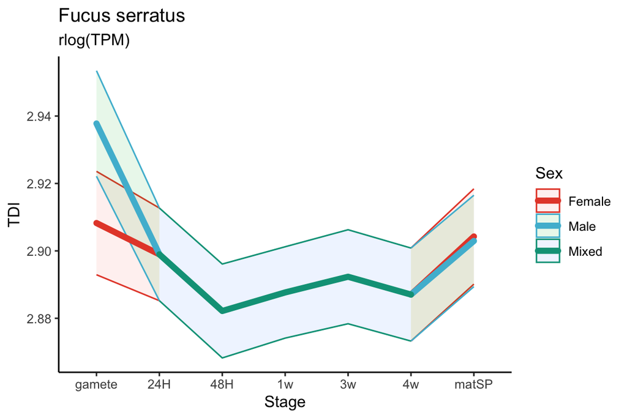

```r
Fs_TDI.rlog %>%
  ggplot2::ggplot(
    aes(
      y = TDI,
      x = Stage,
      group = Sex,
      colour = Sex,
      fill = Sex)) +
  ggplot2::geom_ribbon(
    aes(ymin = TDI - sd,
        ymax = TDI + sd
        ), alpha = 0.1) +
  ggplot2::geom_line(size = 2, lineend = "round") +
  theme_classic() +
  ggsci::scale_colour_npg() +
  labs(title = "Fucus serratus",
       subtitle = "rlog(TPM)")
```

## Fucus distichus

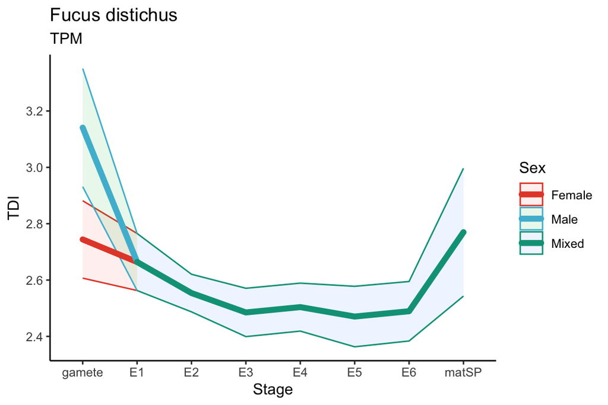

```r
Fd_TDI %>%
  ggplot2::ggplot(
    aes(
      y = TDI,
      x = Stage,
      group = Sex,
      colour = Sex,
      fill = Sex)) +
  ggplot2::geom_ribbon(
    aes(ymin = TDI - sd,
        ymax = TDI + sd
        ), alpha = 0.1) +
  ggplot2::geom_line(size = 2, lineend = "round") +
  theme_classic() +
  ggsci::scale_colour_npg() +
  labs(title = "Fucus distichus",
       subtitle = "TPM")
```

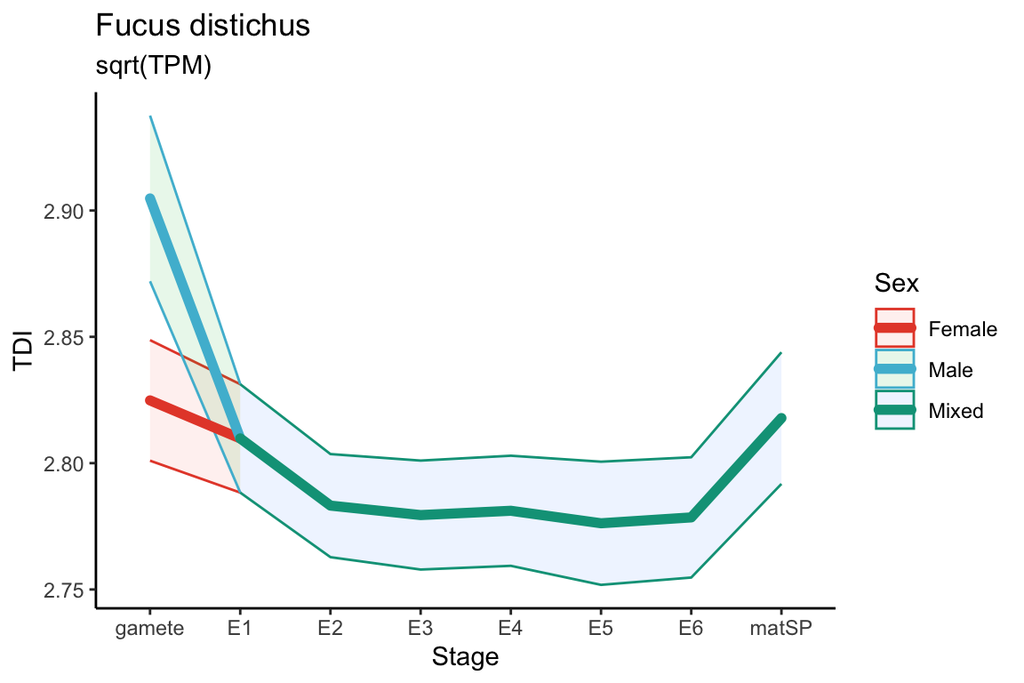

```r
Fd_TDI.sqrt %>%
  ggplot2::ggplot(
    aes(
      y = TDI,
      x = Stage,
      group = Sex,
      colour = Sex,
      fill = Sex)) +
  ggplot2::geom_ribbon(
    aes(ymin = TDI - sd,
        ymax = TDI + sd
        ), alpha = 0.1) +
  ggplot2::geom_line(size = 2, lineend = "round") +
  theme_classic() +
  ggsci::scale_colour_npg() +
  labs(title = "Fucus distichus",
       subtitle = "sqrt(TPM)")
```

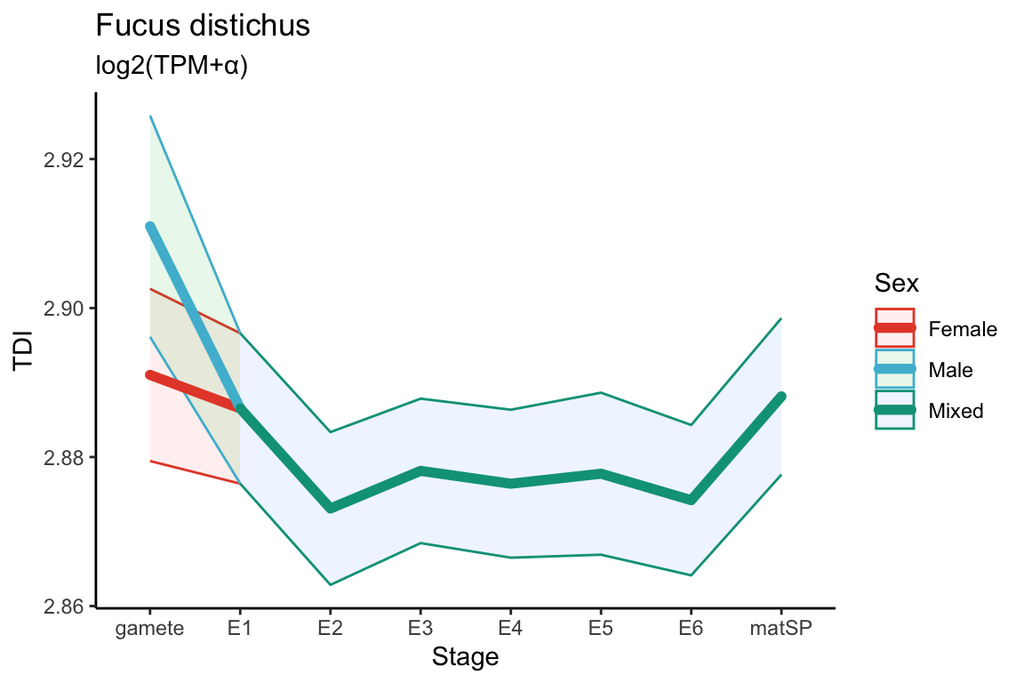

```r
Fd_TDI.log2 %>%
  ggplot2::ggplot(
    aes(
      y = TDI,
      x = Stage,
      group = Sex,
      colour = Sex,
      fill = Sex)) +
  ggplot2::geom_ribbon(
    aes(ymin = TDI - sd,
        ymax = TDI + sd
        ), alpha = 0.1) +
  ggplot2::geom_line(size = 2, lineend = "round") +
  theme_classic() +
  ggsci::scale_colour_npg() +
  labs(title = "Fucus distichus",
       subtitle = "log2(TPM+\u03b1)")
```

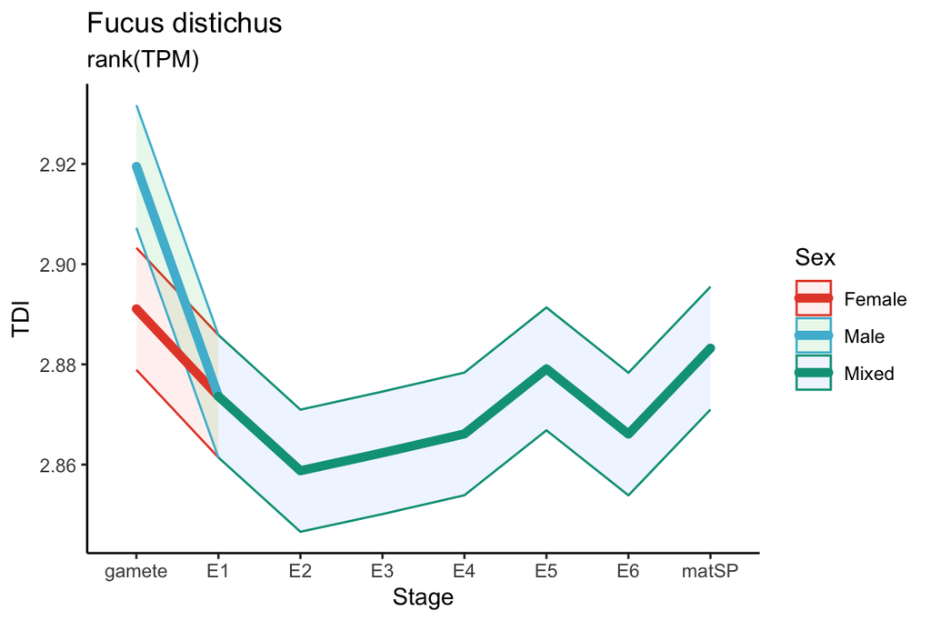

```r
Fd_TDI.rank %>%
  ggplot2::ggplot(
    aes(
      y = TDI,
      x = Stage,
      group = Sex,
      colour = Sex,
      fill = Sex)) +
  ggplot2::geom_ribbon(
    aes(ymin = TDI - sd,
        ymax = TDI + sd
        ), alpha = 0.1) +
  ggplot2::geom_line(size = 2, lineend = "round") +
  theme_classic() +
  ggsci::scale_colour_npg() +
  labs(title = "Fucus distichus",
       subtitle = "rank(TPM)")
```

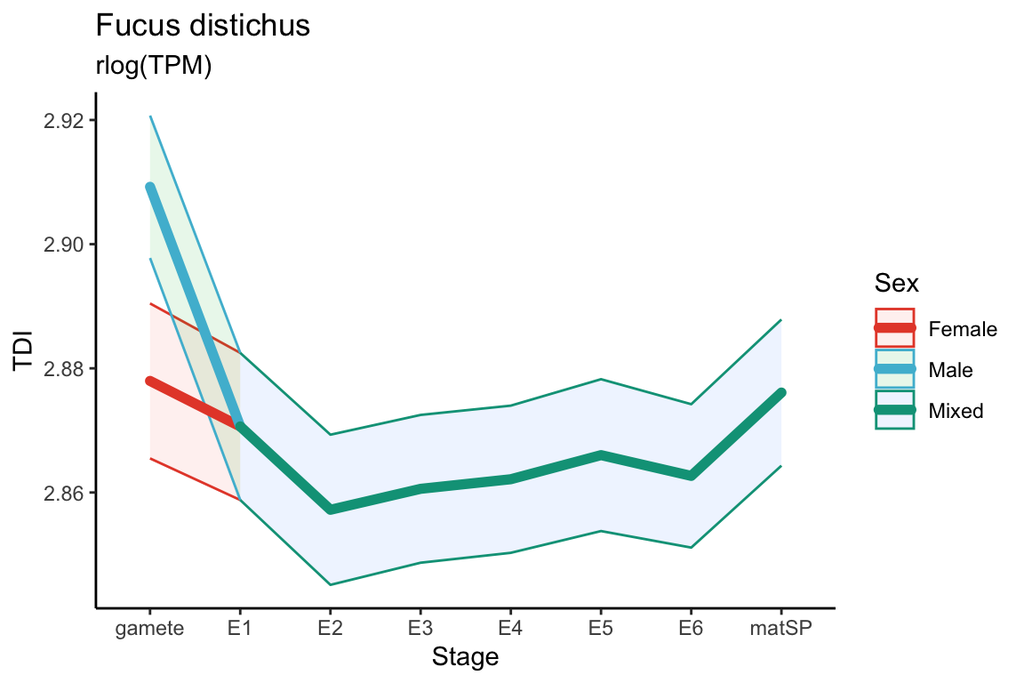

```r
Fd_TDI.rlog %>%
  ggplot2::ggplot(
    aes(
      y = TDI,
      x = Stage,
      group = Sex,
      colour = Sex,
      fill = Sex)) +
  ggplot2::geom_ribbon(
    aes(ymin = TDI - sd,
        ymax = TDI + sd
        ), alpha = 0.1) +
  ggplot2::geom_line(size = 2, lineend = "round") +
  theme_classic() +
  ggsci::scale_colour_npg() +
  labs(title = "Fucus distichus",
       subtitle = "rlog(TPM)")
```

## TDI *Fucus* embryonic stages only

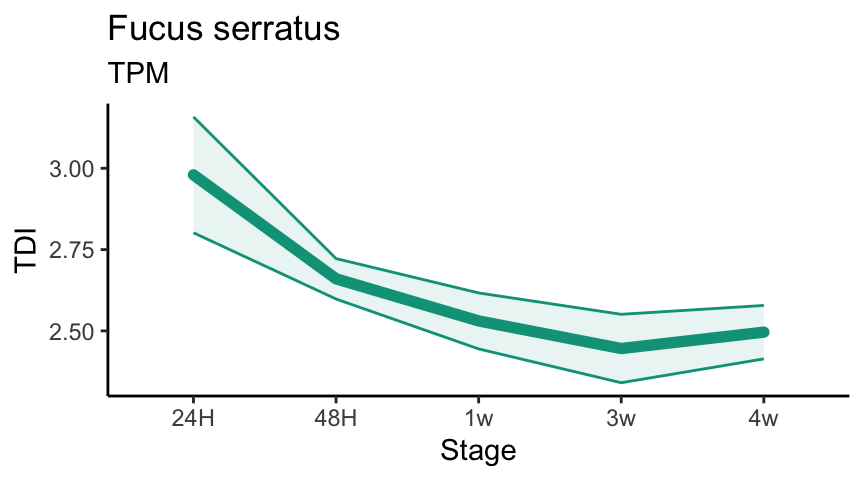

```r
#Fs
Fs_TDI %>%
  dplyr::filter(Stage %in% c("24H", "48H", "1w", "3w", "4w") & Sex == "Mixed") %>%
  ggplot2::ggplot(
    aes(
      y = TDI,
      x = Stage,
      group = 1)) +
  ggplot2::geom_ribbon(
    aes(ymin = TDI - sd,
        ymax = TDI + sd
        ),
    colour = "#00A087FF",
    fill = "#00A087FF",
    alpha = 0.1) +
  ggplot2::geom_line(
    size = 2,
    lineend = "round",
    colour = "#00A087FF") +
  theme_classic() +
  ggsci::scale_colour_npg() +
  labs(title = "Fucus serratus",
       subtitle = "TPM")
```

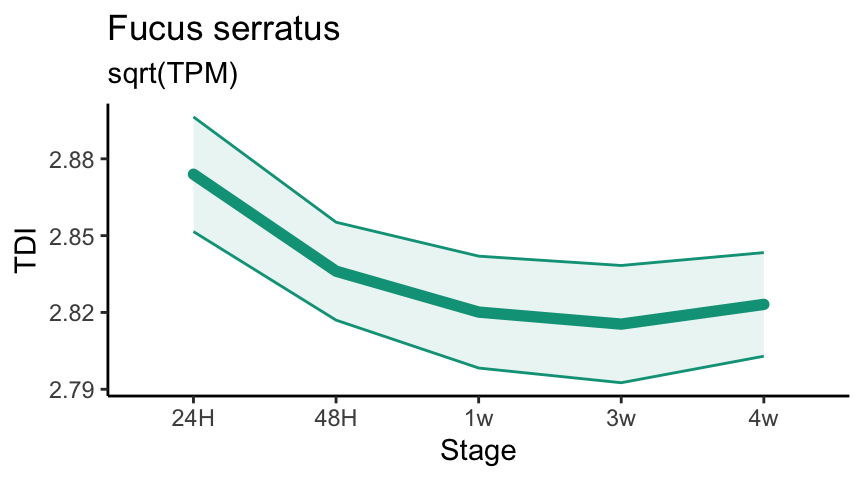

```r
Fs_TDI.sqrt %>%
  dplyr::filter(Stage %in% c("24H", "48H", "1w", "3w", "4w") & Sex == "Mixed") %>%
  ggplot2::ggplot(
    aes(
      y = TDI,
      x = Stage,
      group = 1)) +
  ggplot2::geom_ribbon(
    aes(ymin = TDI - sd,
        ymax = TDI + sd
        ),
    colour = "#00A087FF",
    fill = "#00A087FF",
    alpha = 0.1) +
  ggplot2::geom_line(
    size = 2,
    lineend = "round",
    colour = "#00A087FF") +
  theme_classic() +
  ggsci::scale_colour_npg() +
  labs(title = "Fucus serratus",
       subtitle = "sqrt(TPM)")
```

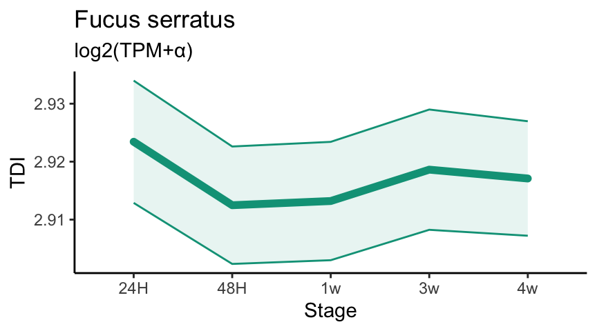

```r
Fs_TDI.log2 %>%
  dplyr::filter(Stage %in% c("24H", "48H", "1w", "3w", "4w") & Sex == "Mixed") %>%
  ggplot2::ggplot(
    aes(
      y = TDI,
      x = Stage,
      group = 1)) +
  ggplot2::geom_ribbon(
    aes(ymin = TDI - sd,
        ymax = TDI + sd
        ),
    colour = "#00A087FF",
    fill = "#00A087FF",
    alpha = 0.1) +
  ggplot2::geom_line(
    size = 2,
    lineend = "round",
    colour = "#00A087FF") +
  theme_classic() +
  ggsci::scale_colour_npg() +
  labs(title = "Fucus serratus",
       subtitle = "log2(TPM+\u03b1)")
```

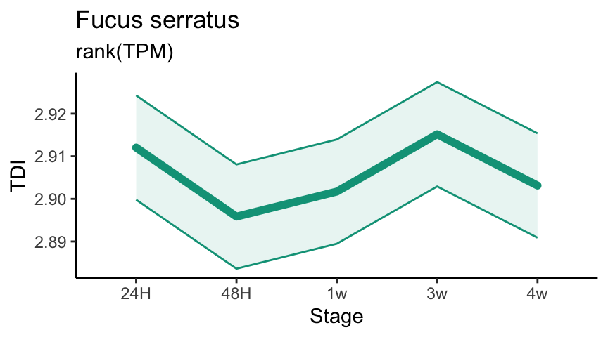

```r
Fs_TDI.rank %>%
  dplyr::filter(Stage %in% c("24H", "48H", "1w", "3w", "4w") & Sex == "Mixed") %>%
  ggplot2::ggplot(
    aes(
      y = TDI,
      x = Stage,
      group = 1)) +
  ggplot2::geom_ribbon(
    aes(ymin = TDI - sd,
        ymax = TDI + sd
        ),
    colour = "#00A087FF",
    fill = "#00A087FF",
    alpha = 0.1) +
  ggplot2::geom_line(
    size = 2,
    lineend = "round",
    colour = "#00A087FF") +
  theme_classic() +
  ggsci::scale_colour_npg() +
  labs(title = "Fucus serratus",
       subtitle = "rank(TPM)")
```

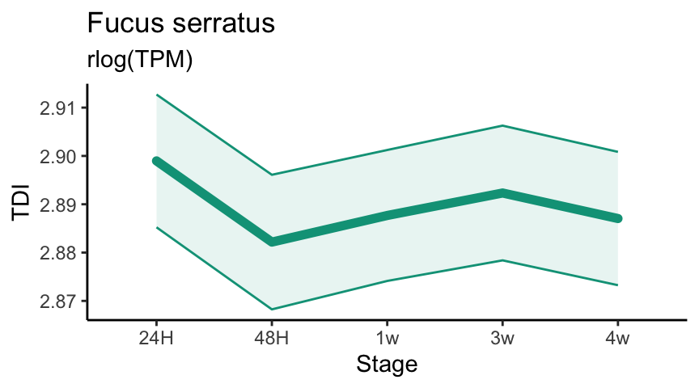

```r
Fs_TDI.rlog %>%
  dplyr::filter(Stage %in% c("24H", "48H", "1w", "3w", "4w") & Sex == "Mixed") %>%
  ggplot2::ggplot(
    aes(
      y = TDI,
      x = Stage,
      group = 1)) +
  ggplot2::geom_ribbon(
    aes(ymin = TDI - sd,
        ymax = TDI + sd
        ),
    colour = "#00A087FF",
    fill = "#00A087FF",
    alpha = 0.1) +
  ggplot2::geom_line(
    size = 2,
    lineend = "round",
    colour = "#00A087FF") +
  theme_classic() +
  ggsci::scale_colour_npg() +
  labs(title = "Fucus serratus",
       subtitle = "rlog(TPM)")
```

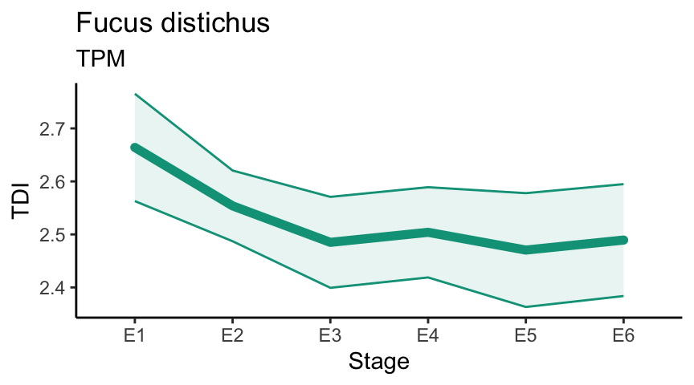

```r
# Fd
Fd_TDI %>%
  dplyr::filter(Stage %in% c("E1", "E2", "E3", "E4", "E5", "E6") & Sex == "Mixed") %>%
  ggplot2::ggplot(
    aes(
      y = TDI,
      x = Stage,
      group = 1)) +
  ggplot2::geom_ribbon(
    aes(ymin = TDI - sd,
        ymax = TDI + sd
        ),
    colour = "#00A087FF",
    fill = "#00A087FF",
    alpha = 0.1) +
  ggplot2::geom_line(
    size = 2,
    lineend = "round",
    colour = "#00A087FF") +
  theme_classic() +
  ggsci::scale_colour_npg() +
  labs(title = "Fucus distichus",
       subtitle = "TPM")
```

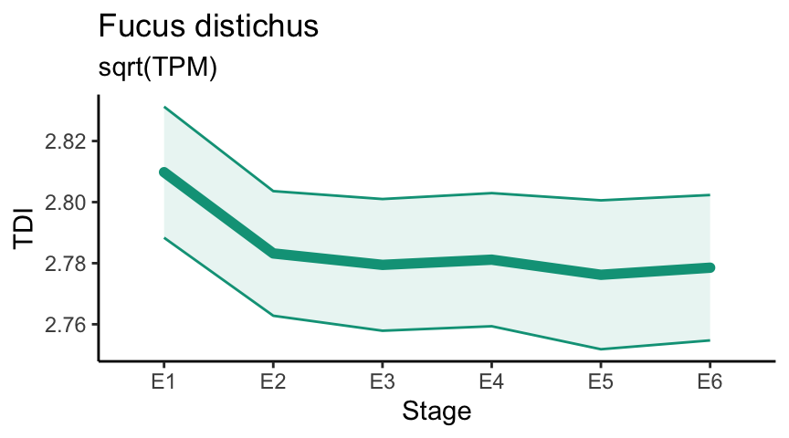

```r
Fd_TDI.sqrt %>%
  dplyr::filter(Stage %in% c("E1", "E2", "E3", "E4", "E5", "E6") & Sex == "Mixed") %>%
  ggplot2::ggplot(
    aes(
      y = TDI,
      x = Stage,
      group = 1)) +
  ggplot2::geom_ribbon(
    aes(ymin = TDI - sd,
        ymax = TDI + sd
        ),
    colour = "#00A087FF",
    fill = "#00A087FF",
    alpha = 0.1) +
  ggplot2::geom_line(
    size = 2,
    lineend = "round",
    colour = "#00A087FF") +
  theme_classic() +
  ggsci::scale_colour_npg() +
  labs(title = "Fucus distichus",
       subtitle = "sqrt(TPM)")
```

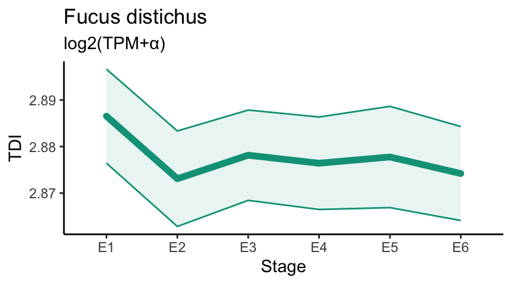

```r
Fd_TDI.log2 %>%
  dplyr::filter(Stage %in% c("E1", "E2", "E3", "E4", "E5", "E6") & Sex == "Mixed") %>%
  ggplot2::ggplot(
    aes(
      y = TDI,
      x = Stage,
      group = 1)) +
  ggplot2::geom_ribbon(
    aes(ymin = TDI - sd,
        ymax = TDI + sd
        ),
    colour = "#00A087FF",
    fill = "#00A087FF",
    alpha = 0.1) +
  ggplot2::geom_line(
    size = 2,
    lineend = "round",
    colour = "#00A087FF") +
  theme_classic() +
  ggsci::scale_colour_npg() +
  labs(title = "Fucus distichus",
       subtitle = "log2(TPM+\u03b1)")
```

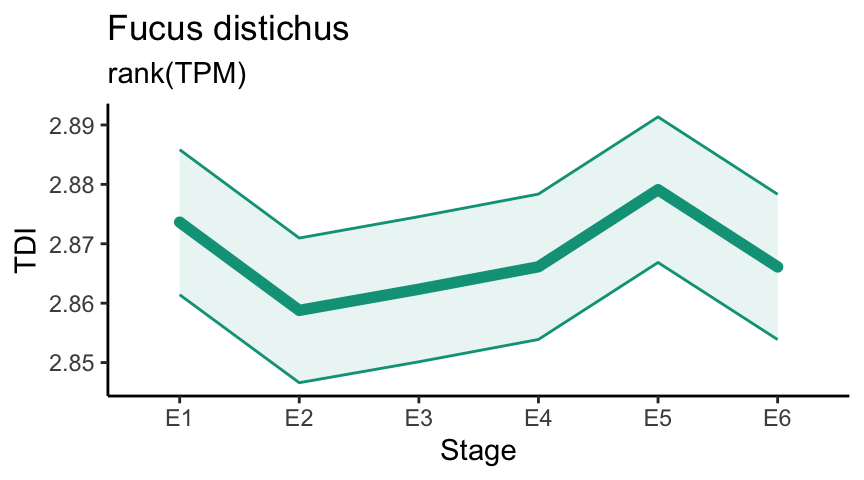

```r
Fd_TDI.rank %>%
  dplyr::filter(Stage %in% c("E1", "E2", "E3", "E4", "E5", "E6") & Sex == "Mixed") %>%
  ggplot2::ggplot(
    aes(
      y = TDI,
      x = Stage,
      group = 1)) +
  ggplot2::geom_ribbon(
    aes(ymin = TDI - sd,
        ymax = TDI + sd
        ),
    colour = "#00A087FF",
    fill = "#00A087FF",
    alpha = 0.1) +
  ggplot2::geom_line(
    size = 2,
    lineend = "round",
    colour = "#00A087FF") +
  theme_classic() +
  ggsci::scale_colour_npg() +
  labs(title = "Fucus distichus",
       subtitle = "rank(TPM)")
```

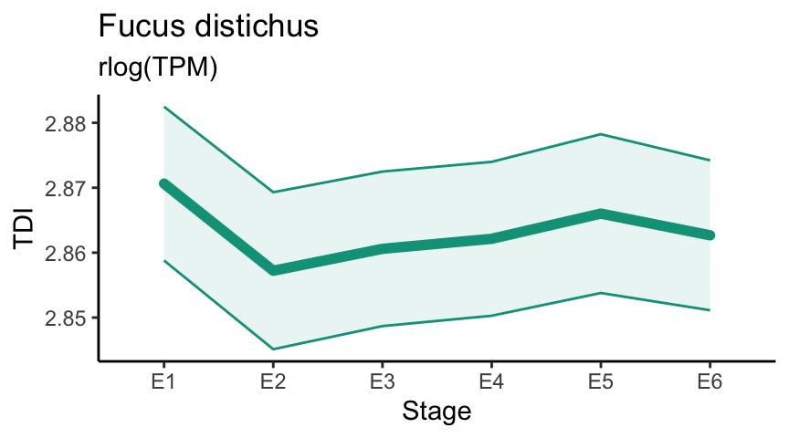

```r
Fd_TDI.rlog %>%
  dplyr::filter(Stage %in% c("E1", "E2", "E3", "E4", "E5", "E6") & Sex == "Mixed") %>%
  ggplot2::ggplot(
    aes(
      y = TDI,
      x = Stage,
      group = 1)) +
  ggplot2::geom_ribbon(
    aes(ymin = TDI - sd,
        ymax = TDI + sd
        ),
    colour = "#00A087FF",
    fill = "#00A087FF",
    alpha = 0.1) +
  ggplot2::geom_line(
    size = 2,
    lineend = "round",
    colour = "#00A087FF") +
  theme_classic() +
  ggsci::scale_colour_npg() +
  labs(title = "Fucus distichus",
       subtitle = "rlog(TPM)")
```

## Ectocarpus

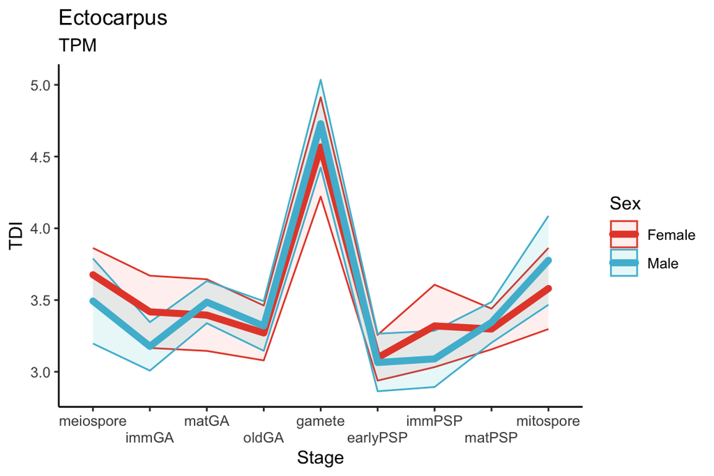

```r
Ec_TDI %>%
  ggplot2::ggplot(
    aes(
      y = TDI,
      x = Stage,
      group = Sex,
      colour = Sex,
      fill = Sex)) +
  ggplot2::geom_ribbon(
    aes(ymin = TDI - sd,
        ymax = TDI + sd
        ), alpha = 0.1) +
  ggplot2::geom_line(size = 2, lineend = "round") +
  theme_classic() +
  ggsci::scale_colour_npg() +
  ggplot2::scale_x_discrete(guide = ggplot2::guide_axis(n.dodge=2)) +
  labs(title = "Ectocarpus",
       subtitle = "TPM")
```

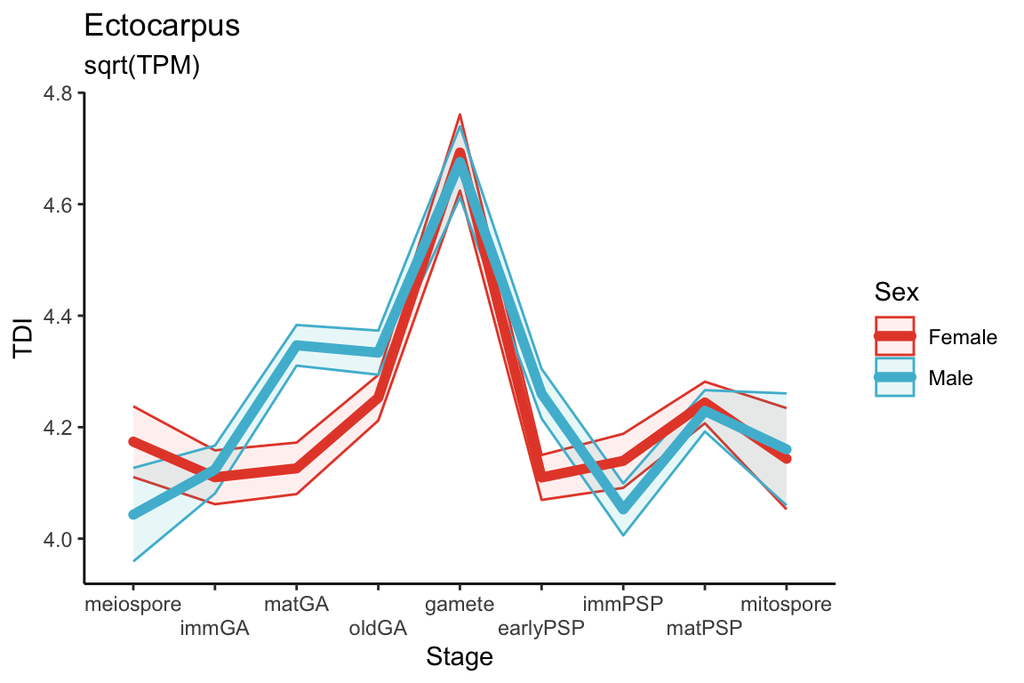

```r
Ec_TDI.sqrt %>%
  ggplot2::ggplot(
    aes(
      y = TDI,
      x = Stage,
      group = Sex,
      colour = Sex,
      fill = Sex)) +
  ggplot2::geom_ribbon(
    aes(ymin = TDI - sd,
        ymax = TDI + sd
        ), alpha = 0.1) +
  ggplot2::geom_line(size = 2, lineend = "round") +
  theme_classic() +
  ggsci::scale_colour_npg() +
  ggplot2::scale_x_discrete(guide = ggplot2::guide_axis(n.dodge=2)) +
  labs(title = "Ectocarpus",
       subtitle = "sqrt(TPM)")
```

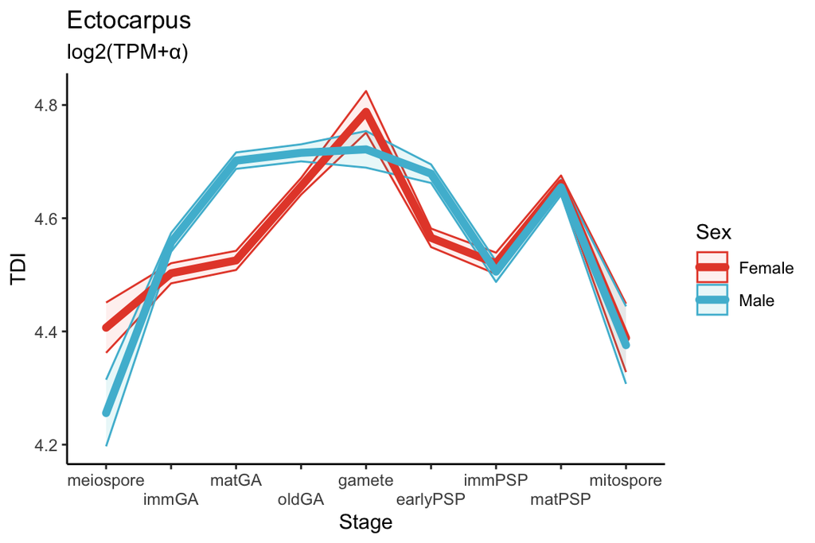

```r
Ec_TDI.log2 %>%
  ggplot2::ggplot(
    aes(
      y = TDI,
      x = Stage,
      group = Sex,
      colour = Sex,
      fill = Sex)) +
  ggplot2::geom_ribbon(
    aes(ymin = TDI - sd,
        ymax = TDI + sd
        ), alpha = 0.1) +
  ggplot2::geom_line(size = 2, lineend = "round") +
  theme_classic() +
  ggsci::scale_colour_npg() +
  ggplot2::scale_x_discrete(guide = ggplot2::guide_axis(n.dodge=2)) +
  labs(title = "Ectocarpus",
       subtitle = "log2(TPM+\u03b1)")
```

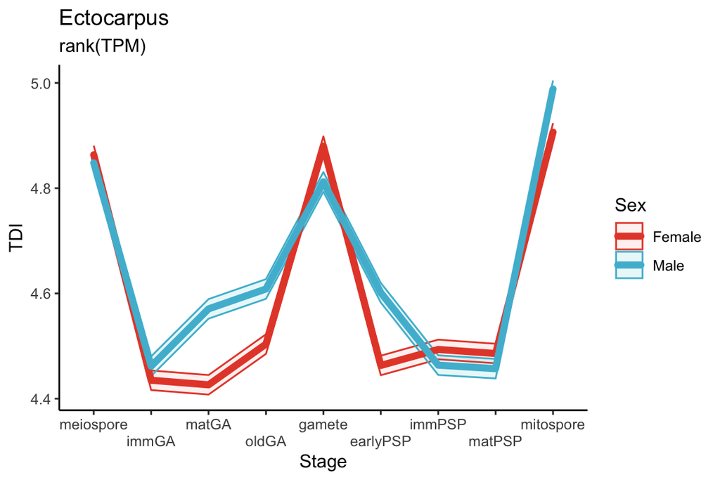

```r
Ec_TDI.rank %>%
  ggplot2::ggplot(
    aes(
      y = TDI,
      x = Stage,
      group = Sex,
      colour = Sex,
      fill = Sex)) +
  ggplot2::geom_ribbon(
    aes(ymin = TDI - sd,
        ymax = TDI + sd
        ), alpha = 0.1) +
  ggplot2::geom_line(size = 2, lineend = "round") +
  theme_classic() +
  ggsci::scale_colour_npg() +
  ggplot2::scale_x_discrete(guide = ggplot2::guide_axis(n.dodge=2)) +
  labs(title = "Ectocarpus",
       subtitle = "rank(TPM)")
```

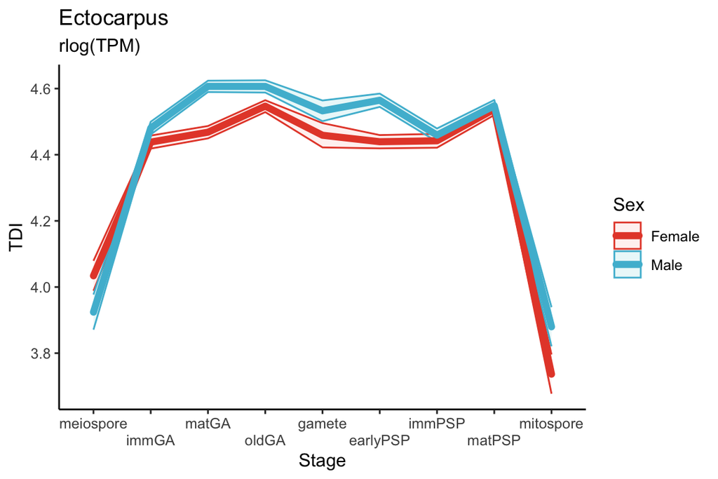

```r
Ec_TDI.rlog %>%
  ggplot2::ggplot(
    aes(
      y = TDI,
      x = Stage,
      group = Sex,
      colour = Sex,
      fill = Sex)) +
  ggplot2::geom_ribbon(
    aes(ymin = TDI - sd,
        ymax = TDI + sd
        ), alpha = 0.1) +
  ggplot2::geom_line(size = 2, lineend = "round") +
  theme_classic() +
  ggsci::scale_colour_npg() +
  ggplot2::scale_x_discrete(guide = ggplot2::guide_axis(n.dodge=2)) +
  labs(title = "Ectocarpus",
       subtitle = "rlog(TPM)")
```

The r-log is behaving weird because the transformation is non-linear but also does not preserve the *monotonic* relationship.

# tfStability

## Flat line test

*F. serratus*

```r
Fs_DES_tS <-
  tfStability(
    dplyr::select(Fs_DES, !c(gamete, matSP)),
    transforms = c("none", "sqrt", "log2", "rank"),
    permutations = 50000
    )
Fs_DES_tS_processed <-
  tibble::as_tibble(Fs_DES_tS, rownames = "transformation")

Fs_DES_tS.rlog <-
  tfStability(
    dplyr::select(Fs_DES.rlog, !c(gamete, matSP)),
    transforms = c("none"), # it is already transformed.
    permutations = 50000
    )
Fs_DES_tS.rlog_processed <-
  tibble::as_tibble(Fs_DES_tS.rlog, rownames = "transformation") %>%
  dplyr::mutate(transformation = "rlog")

Fs_DES_tS_res <-
  dplyr::bind_rows(Fs_DES_tS_processed, Fs_DES_tS.rlog_processed) %>%
  dplyr::rename("pval" = value) %>%
  dplyr::mutate(test = "FlatLineTest")
```

*F. distichus*

```r
Fd_DES_tS <-
  tfStability(
    dplyr::select(Fd_DES, !c(gamete, matSP)),
    transforms = c("none", "sqrt", "log2", "rank"),
    permutations = 50000
    )
Fd_DES_tS_processed <-
  tibble::as_tibble(Fd_DES_tS, rownames = "transformation")

Fd_DES_tS.rlog <-
  tfStability(
    dplyr::select(Fd_DES.rlog, !c(gamete, matSP)),
    transforms = c("none"), # it is already transformed.
    permutations = 50000
    )
Fd_DES_tS.rlog_processed <-
  tibble::as_tibble(Fd_DES_tS.rlog, rownames = "transformation") %>%
  dplyr::mutate(transformation = "rlog")

Fd_DES_tS_res <-
  dplyr::bind_rows(Fd_DES_tS_processed, Fd_DES_tS.rlog_processed) %>%
  dplyr::rename("pval" = value) %>%
  dplyr::mutate(test = "FlatLineTest")
```

*Ectocarpus*

```r
# female
Ec_DES_25f_tS <-
  tfStability(
    Ec_DES_25f,
    transforms = c("none", "sqrt", "log2", "rank"),
    permutations = 50000
    )
Ec_DES_25f_tS_processed <-
  tibble::as_tibble(Ec_DES_25f_tS, rownames = "transformation")

Ec_DES_25f_tS.rlog <-
  tfStability(
    Ec_DES_25f.rlog,
    transforms = c("none"), # it is already transformed.
    permutations = 50000
    )
Ec_DES_25f_tS.rlog_processed <-
  tibble::as_tibble(Ec_DES_25f_tS.rlog, rownames = "transformation") %>%
  dplyr::mutate(transformation = "rlog")

Ec_DES_25f_tS_res <-
  dplyr::bind_rows(Ec_DES_25f_tS_processed, Ec_DES_25f_tS.rlog_processed) %>%
  dplyr::rename("pval" = value) %>%
  dplyr::mutate(test = "FlatLineTest")

# male
Ec_DES_32m_tS <-
  tfStability(
    Ec_DES_32m,
    transforms = c("none", "sqrt", "log2", "rank"),
    permutations = 50000
    )
Ec_DES_32m_tS_processed <-
  tibble::as_tibble(Ec_DES_32m_tS, rownames = "transformation")

Ec_DES_32m_tS.rlog <-
  tfStability(
    Ec_DES_32m.rlog,
    transforms = c("none"), # it is already transformed.
    permutations = 50000
    )
Ec_DES_32m_tS.rlog_processed <-
  tibble::as_tibble(Ec_DES_32m_tS.rlog, rownames = "transformation") %>%
  dplyr::mutate(transformation = "rlog")

Ec_DES_32m_tS_res <-
  dplyr::bind_rows(Ec_DES_32m_tS_processed, Ec_DES_32m_tS.rlog_processed) %>%
  dplyr::rename("pval" = value) %>%
  dplyr::mutate(test = "FlatLineTest")
```